# BR02

Xinqian Cai

2021/9/26

## Exercise 2.1

1. $$P(B|A) > P(B)$$
   If a person enjoy an award-winning books, it means that he likes this author’s writing style. Therefore, he will be more probable to be interested in the same author’s book.
2. $$P(B|A) < P(B)$$
   Given today’s temperature is 0 degrees Fahrenheit, it is less likely that tomorrow’s temperature will suddenly get to 60 degrees.
3. $$P(B|A) > P(B)$$
   If the authors only got 3 hours of sleep last night, it will be more likely that the authors will make several typos today because sleeping less will cause disattraction.
4. $$P(B|A) > P(B)$$
   If my friend includes three hashtags in their tweets, the tweet is more likely to get retweeted. Because the more the number of hashtags is, the more people see this tweet.

## Exercise 2.2

1. $$P(B|A) = 0.73$$
   This is a conditional probability.
2. $$P(A) = 0.2$$
   This is a marginal probability.
3. $$P(D) = 0.15$$
   This is a marginal probability.
4. $$P(C|D) = 0.91$$
   This is a conditional probability.
5. $$P(F∩E)$$
   This is a joint probability.
6. $$P(E|F)$$
   This is a conditional probability.

## Exercise 2.3

1. $$Y|π ∼ Bin(6,π)$$
2. $$Y|0.9 ∼ Bin(27,0.9)$$
3. $$Y|0.17 ∼ Bin(n,0.17)$$
4. The binomial model is not appropriate here because I do not know whether Henry has the equal probability of be late each time.
5. $$Y|π(hate to be center) ∼ Bin(n,π)$$
6. $$Y|0.8 ∼ Bin(60,0.8)$$

## Exercise 2.4

```r
ve <- 0.05
nve <- 0.95
sp_ve <- 0.7
sp_nve <- 0.03
ve_sp <- ve*sp_ve/(ve*sp_ve+nve*sp_nve)
ve_sp
```

```
## [1] 0.5511811
```

Given that Edward sparkled like a diamond, the probability that vampire exist is about 55.12%.

## Exercise 2.5

1. The prior probability that the selected tree has mold is 18%.

```r
inf <- 0.18
inf_maple <- 0.8
ninf <- 0.82
ninf_maple <- 0.1

mapple <- inf*inf_maple + ninf*ninf_maple
mapple
```

```
## [1] 0.226
```

The probability that the employee would have selected a maple is 22.6%.

```r
inf*inf_maple/(inf_maple*inf + ninf_maple*ninf)
```

```
## [1] 0.6371681
```

The posterior probability that the elected maple tree has mold is about 63.7%.

d.Given the selected tree is a maple tree, the probability of the tree having mold increases from 18% to 63.7% because the trees with mold is more likely to be maples (80%) while only 10 percent of healthy trees are maples. The maples trees is more compatible with the trees having mold.

## Exercise 2.6

The necessary information is the percentage of fewer than 4 stars restaurant among the restaurants Sandra does not like.

## Exercise 2.7

```r
right <- 0.08
nright <- 0.92
r_nonbinary <- 0.2
nr_nonbinary <- 0.1

nonbinary <- right*r_nonbinary + nright*nr_nonbinary
nonbinary
```

```
## [1] 0.108
```

The probability that a randomly chosen person on this dating app is nonbinary is 10.8%.

```r
right*r_nonbinary/(right*r_nonbinary + nright*nr_nonbinary)
```

```
## [1] 0.1481481
```

The posterior probability that he swipes right given that the profile is nonbinary is about 14.8%.

## Exercise 2.8

```r
del <- 0.15
del_morning <- 0.4
morning <- 0.3

del*del_morning/morning
```

```
## [1] 0.2
```

The probability that Mine’s flight will be delayed is 20%.

```r
ndel <- 0.85
ndel_morning <- (morning - del_morning*del)/ndel
morning*ndel_morning/ndel
```

```
## [1] 0.09965398
```

The probability that Alicia is on a morning flight is 9.965%.

## Exercise 2.9

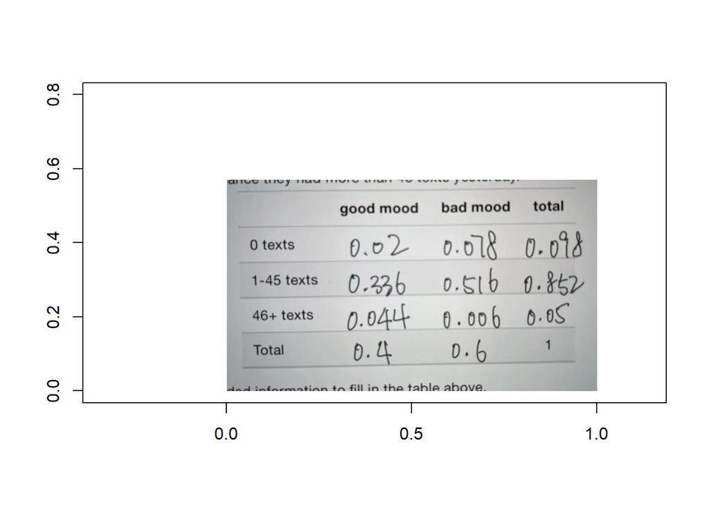

```r
library(png)
diagram <- readPNG("D:/excel01.png")
r <- nrow(diagram)/ncol(diagram)
plot(c(0,0.8), c(0,0.8), type = "n", xlab = "", ylab = "", asp = 1)
rasterImage(diagram, 0, 0, 1, r)
```

b.The probability that the roommate is in a good mood is 40%. This is the prior part of the Bayes’ Rule equation.

3. If they are in good mood today, the probability that they received 50 texts yesterday is 11%. This is the likelihood part.

```r
gm <- 0.4
gm_50 <- 0.11
fiftytexts <- 0.05

gm*gm_50/fiftytexts
```

```
## [1] 0.88
```

Given the roomate received 50 messages yesterday, the posterior probability that they are in a good mood is 88%.

## Exercise 2.10

```r
rural <- 0.085
urban <- 0.0915
rural_L <- 0.1
urban_L <- 0.105

LGBTQ <- rural*rural_L + urban*urban_L
LGBTQ
```

```
## [1] 0.0181075
```

The probability they identify as LGBTQ is about 1.81%

```r
rural*rural_L/LGBTQ
```

```
## [1] 0.4694187
```

If they identify as LGBTQ, the probability that they live in a rural area is about 46.94%.

```r
nLGBTQ <- 1-LGBTQ
rural_nLGBTQ <- 1-rural_L
rural*rural_nLGBTQ/nLGBTQ
```

```
## [1] 0.07791077
```

If they do not identify as LGBTQ, the probability that they live in a rural area is about 7.79%.

## Exercise 2.11

1. $$Y|π ∼ Bin(6,π)$$
   $$f(y|π) = (6 choose y) * π^y * (1-π)^(6-y)$$
   for y∈{0,1,2,3,4,5,6}, π∈{0.3, 0.4, 0.5}

```r
lik_0.3 = choose(6,4)*0.3^4*(0.7^2)
lik_0.3
```

```
## [1] 0.059535
```

3. $$L(π|y = 4) = f(4|π) = (6 choose 4) * π^4 * (1-π)^(6-4)$$
   Exercise 2.12 a.
   $$Y|π ∼ Bin(7,π)$$
   $$f(y|π) = (7 choose y) * π^y * (1-π)^(7-y)$$
   for y∈{0,1,2,3,4,5,6,7}, π∈{0.1, 0.25, 0.4}

```r
p <- c(0.1, 0.25, 0.4)
lik <- dbinom(1,7,p)
lik
```

```
## [1] 0.3720087 0.3114624 0.1306368
```

```r
# calculate the normalizing constant
fy1 <- 0.2*0.372 + 0.45*0.311 +0.35*0.131
fy1
```

```
## [1] 0.2602
```

```r
pmf_0.1 <- 0.2*0.372/fy1
pmf_0.25 <- 0.45*0.311/fy1
pmf_0.4 <- 0.35*0.131/fy1
pmf_0.1
```

```
## [1] 0.2859339
```

```r
pmf_0.25
```

```
## [1] 0.5378555
```

```r
pmf_0.4
```

```
## [1] 0.1762106
```

c.The posterior have likelhood part and nominalizing constant part that the prior model does not have.

```r
# calculate the normalizing constant
fy1_K <- 0.15*0.372 + 0.15*0.311 +0.7*0.131

pmf_0.1 <- 0.15*0.372/fy1_K
pmf_0.25 <- 0.15*0.311/fy1_K
pmf_0.4 <- 0.15*0.131/fy1_K
pmf_0.1
```

```
## [1] 0.2874066
```

```r
pmf_0.25
```

```
## [1] 0.2402781
```

```r
pmf_0.4
```

```
## [1] 0.1012104
```

Compared with Miles, if Kris only succeed once in 7 times, the probability that he would be less likely that he is a master in making mugs (0.101) than Miles (0.17).

## Exercise 13

1. The posterior model of π = 0.6 will increase most, and that of π = 0.4 and π = 0.5 will decrease because the 47/80 is more close to 0.6.

```r
p <- c(0.4, 0.5, 0.6, 0.7)
lik13 <- dbinom(47,80,p)
lik13
```

```
## [1] 0.0003014292 0.0263617861 0.0879960072 0.0092893167
```

```r
# calculate the normalizing constant
nc13 <- 0.1* 0.0003 + 0.5*0.0264 + 0.6*0.088 + 0.26*0.0093

pmf_0.4_exercise13b <- 0.1*0.0003/nc13
pmf_0.5_exercise13b <- 0.5*0.0264/nc13
pmf_0.6_exercise13b <- 0.6*0.088/nc13
pmf_0.7_exercise13b <- 0.26*0.0093/nc13

pmf_0.4_exercise13b
```

```
## [1] 0.0004382889
```

```r
pmf_0.5_exercise13b
```

```
## [1] 0.1928471
```

```r
pmf_0.6_exercise13b
```

```
## [1] 0.7713885
```

```r
pmf_0.7_exercise13b
```

```
## [1] 0.03532609
```

My guess is close to the posterior model results.

```r
p <- c(0.4, 0.5, 0.6, 0.7)
lik13c <- dbinom(470,800,p)
```

```r
nc13c <- 0.1* 4.914875e-27 + 0.5*1.286493e-07 + 0.6*2.209473e-02 + 0.26*3.797491e-12

pmf_0.4_exercise13c <- 0.1*4.914875e-27/nc13
pmf_0.5_exercise13c <- 0.5*1.286493e-07/nc13
pmf_0.6_exercise13c <- 0.6*2.209473e-02/nc13
pmf_0.7_exercise13c <- 0.26*3.797491e-12/nc13

pmf_0.4_exercise13c
```

```
## [1] 7.180451e-27
```

```r
pmf_0.5_exercise13c
```

```
## [1] 9.397594e-07
```

```r
pmf_0.6_exercise13c
```

```
## [1] 0.1936775
```

```r
pmf_0.7_exercise13c
```

```
## [1] 1.442478e-11
```

The probability of 0.4, 0.5, 0.7 become extremely low and the probability of 0.6 extrude.

## Exercise 14

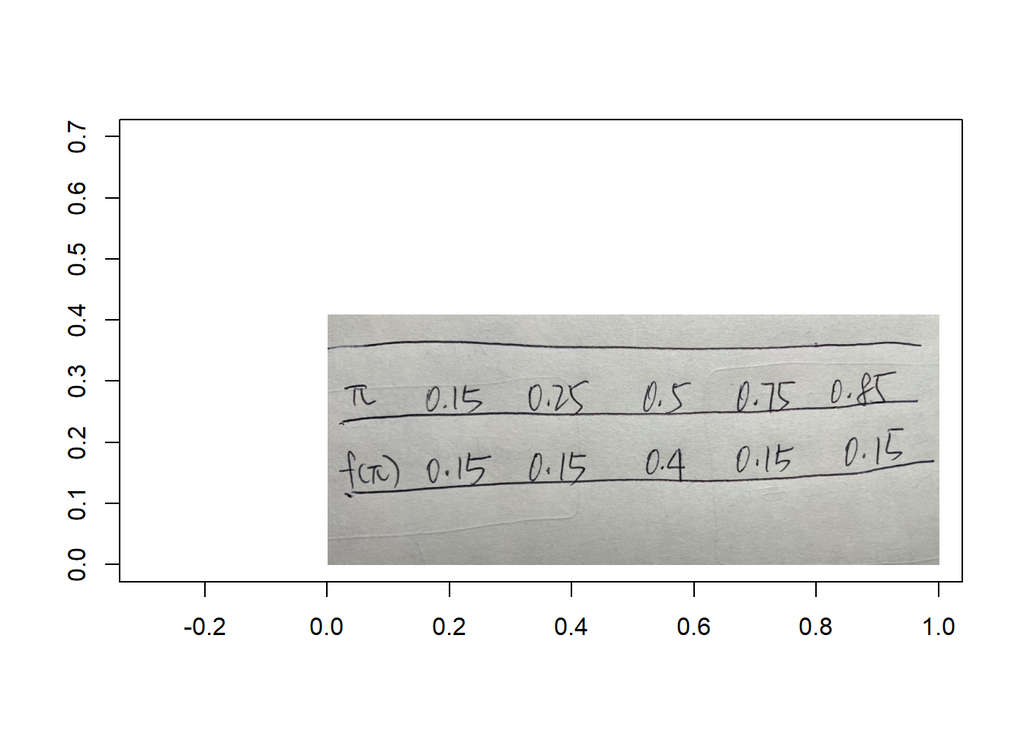

```r
diagram <- readPNG("D:/exercise14png.png")
r <- nrow(diagram)/ncol(diagram)
plot(c(0,0.7), c(0,0.7), type = "n", xlab = "", ylab = "", asp = 1)
rasterImage(diagram, 0, 0, 1, r)
```

```r
p <- c(0.15, 0.25, 0.5, 0.75, 0.85)
lik14 <- dbinom(3,13,p)
lik14
```

```
## [1] 1.900330e-01 2.516510e-01 3.491211e-02 1.150668e-04 1.012827e-06
```

```r
# Calculate the normalizing constant
nc14 <- 0.15*1.900330e-01 + 0.15*2.516510e-01 +0.4*3.491211e-02 + 0.15*1.150668e-04 + 0.15*1.012827e-06

# calculate the posterior results of each π
pmf_0.15_exercise14 <- 0.15*1.900330e-01 /nc14
pmf_0.25_exercise14 <- 0.15*2.516510e-01/nc14
pmf_0.5_exercise14 <- 0.4*3.491211e-02/nc14
pmf_0.75_exercise14 <- 0.15*1.150668e-04/nc14
pmf_0.85_exercise14 <- 0.15*1.012827e-06/nc14

pmf_0.15_exercise14
```

```
## [1] 0.3552689
```

```r
pmf_0.25_exercise14
```

```
## [1] 0.4704645
```

```r
pmf_0.5_exercise14
```

```
## [1] 0.1740496
```

```r
pmf_0.75_exercise14
```

```
## [1] 0.0002151187
```

```r
pmf_0.85_exercise14
```

```
## [1] 1.893492e-06
```

## Exercise 15

1. The probability that π = 0.7 and π = 0.75 will increase while the probability that π = 0.6 and π = 0.65 will decrease.
2. The probability that π = 0.7 and π = 0.75 will decrease while the probability that π = 0.6 and π = 0.65 will increase.

```r
# calculate the likelihood
p <- c(0.6, 0.65, 0.7, 0.75)
lik15 <- dbinom(10,15,p)
lik15
```

```
## [1] 0.1859378 0.2123387 0.2061304 0.1651460
```

```r
# Calculate the normalizing constant
nc15 <- 0.3*0.1859378 + 0.4*0.2123387 +0.2*0.2061304 + 0.1*0.1651460

# calculate the posterior results of each π
pmf_0.6_exercise15 <- 0.3*0.1859378 /nc15
pmf_0.65_exercise15 <- 0.4*0.2123387/nc15
pmf_0.7_exercise15 <- 0.2*0.2061304/nc15
pmf_0.75_exercise15 <- 0.1*0.1651460/nc15


pmf_0.6_exercise15
```

```
## [1] 0.2810745
```

```r
pmf_0.65_exercise15
```

```
## [1] 0.4279782
```

```r
pmf_0.7_exercise15
```

```
## [1] 0.2077325
```

```r
pmf_0.75_exercise15
```

```
## [1] 0.08321479
```

d.The likelihood part is evaluating the compatibility of each π with the fact that 10 out of 15 hatchlings would survive for at least 1 week. The normalizing constant “nc15” is used to balance the likelihood and prior model, which can be more easy for us to do comparison.

## Exercise 2.16

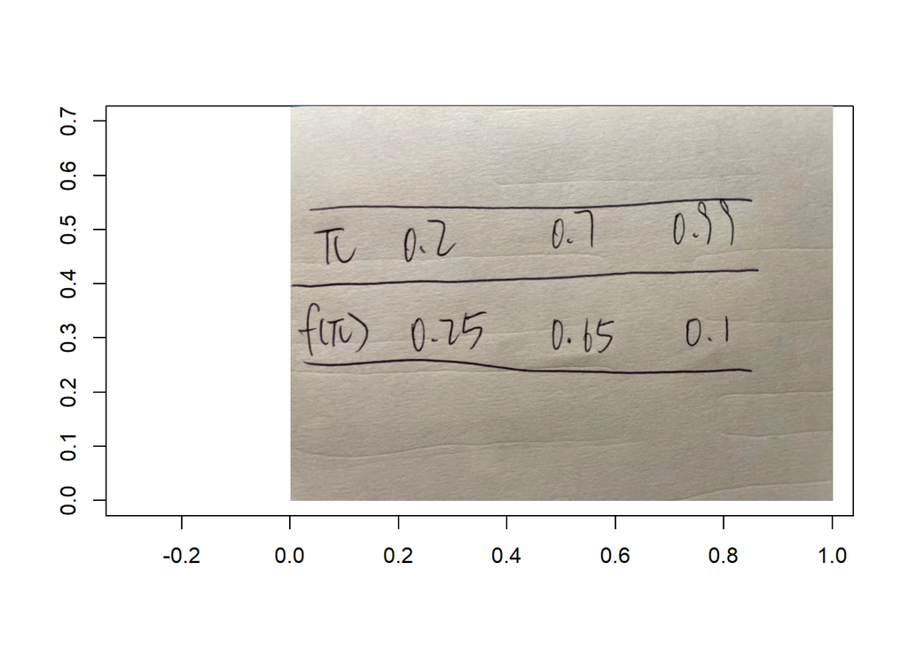

```r
diagram <- readPNG("D:/exercise16png.png")
r <- nrow(diagram)/ncol(diagram)
plot(c(0,0.7), c(0,0.7), type = "n", xlab = "", ylab = "", asp = 1)
rasterImage(diagram, 0, 0, 1, r)
```

2. The values of π are different and the function of π, f(π)，is different, too.

```r
f <- c(1:10)

choose(10,f)* 0.6^f * 0.4^(10-f)
```

```
##  [1] 0.001572864 0.010616832 0.042467328 0.111476736 0.200658125 0.250822656
##  [7] 0.214990848 0.120932352 0.040310784 0.006046618
```

Based on the results above, it is easy to see that the minimum number is 3 so that f(π = 0.6|Y = y) > 0.4.

## Exercise 2.17

```r
library(dplyr)
library(janitor)
# Define possible status
tree <- data.frame(type = c("mold", "healthy"))
# Define the prior model
prior <- c(0.18, 0.82)
# Simulate 10,000 trees
set.seed(10)
tree_sim <- sample_n(tree, size = 10000, weight = prior, replace = TRUE)

tree_sim |>
  tabyl(type) |>
  adorn_totals("row")
```

```
##     type     n percent
##  healthy  8129  0.8129
##     mold  1871  0.1871
##    Total 10000  1.0000
```

```r
tree_sim <- tree_sim |>
  mutate(maple = case_when(type == "mold" ~ 0.8,type == "healthy" ~ 0.1))
glimpse(tree_sim)
```

```
## Rows: 10,000
## Columns: 2
## $ type  <chr> "healthy", "healthy", "healthy", "healthy", "healthy", "healthy"~
## $ maple <dbl> 0.1, 0.1, 0.1, 0.1, 0.1, 0.1, 0.1, 0.1, 0.1, 0.1, 0.1, 0.1, 0.1,~
```

```r
data <- c("maple", "no maple")
set.seed(11)
tree_sim <- tree_sim |>
  group_by(1:n()) |>
  mutate(mapleornot = sample(data, size = 1,
                        prob = c(1 - maple, maple)))
tree_sim |>
  tabyl(mapleornot, type) %>%
  adorn_totals(c("col","row"))
```

```
##  mapleornot healthy mold Total
##       maple    7295  349  7644
##    no maple     834 1522  2356
##       Total    8129 1871 10000
```

```r
tree_sim |>
  filter(mapleornot == "maple") |>
  tabyl(type) |>
  adorn_totals("row")
```

```
##     type    n    percent
##  healthy 7295 0.95434328
##     mold  349 0.04565672
##    Total 7644 1.00000000
```

## Exercise 2.18

```r
# Define possible win probabilities
Lac <- data.frame(pi = c(0.4, 0.5, 0.6, 0.7))

# Define the prior model
prior <- c(0.1, 0.2, 0.44, 0.26)

# Simulate 10000 values of pi from the prior
set.seed(20)
Lac_sim <- sample_n(Lac, size = 10000, weight = prior, replace = TRUE)

# Simulate 10000 match outcomes
Lac_sim <- Lac_sim |>
  mutate(y = rbinom(10000, size = 80, prob = pi))

# Summarize the prior
Lac_sim |>
  tabyl(pi) |>
  adorn_totals("row")
```

```
##     pi     n percent
##    0.4  1011  0.1011
##    0.5  2023  0.2023
##    0.6  4412  0.4412
##    0.7  2554  0.2554
##  Total 10000  1.0000
```

```r
# Focus on simulations with y = 47
lac_47 <- Lac_sim |>
  filter(y == 47)

# Summarize the posterior approximation
lac_47 |>
  tabyl(pi) |>
  adorn_totals("row")
```

```
##     pi   n     percent
##    0.4   1 0.002247191
##    0.5  57 0.128089888
##    0.6 364 0.817977528
##    0.7  23 0.051685393
##  Total 445 1.000000000
```

## Exercise 2.19

```r
# Define possible win probabilities
surv <- data.frame(pi = c(0.6, 0.65, 0.7, 0.75))

# Define the prior model
prior <- c(0.3, 0.4, 0.2, 0.1)

# Simulate 10000 values of pi from the prior
set.seed(19)
surv_sim <- sample_n(surv, size = 10000, weight = prior, replace = TRUE)

# Simulate 10000 match outcomes
surv_sim <- surv_sim |>
  mutate(y = rbinom(10000, size = 15, prob = pi))

# Summarize the prior
surv_sim |>
  tabyl(pi) |>
  adorn_totals("row")
```

```
##     pi     n percent
##    0.6  3040  0.3040
##   0.65  3976  0.3976
##    0.7  1995  0.1995
##   0.75   989  0.0989
##  Total 10000  1.0000
```

```r
# Focus on simulations with y = 10
surv_10 <- surv_sim |>
  filter(y == 10)

# Summarize the posterior approximation
surv_10 |>
  tabyl(pi) |>
  adorn_totals("row")
```

```
##     pi    n    percent
##    0.6  530 0.26368159
##   0.65  863 0.42935323
##    0.7  441 0.21940299
##   0.75  176 0.08756219
##  Total 2010 1.00000000
```

## Exercise 2.20

```r
# Define possible status
image <- data.frame(type = c("cat", "noncat"))
# Define the prior model
prior <- c(0.08, 0.92)
# Simulate 10,000 images
set.seed(20)
image_sim <- sample_n(image, size = 10000, weight = prior, replace = TRUE)

image_sim |>
  tabyl(type) |>
  adorn_totals("row")
```

```
##    type     n percent
##     cat   811  0.0811
##  noncat  9189  0.9189
##   Total 10000  1.0000
```

```r
image_sim <- image_sim |>
  mutate(algorithm = case_when(type == "cat" ~ 0.8,type == "noncat" ~ 0.5))

data <- c("correct", "wrong")
set.seed(30)
image_sim <- image_sim |>
  group_by(1:n()) |>
  mutate(algorithmornot = sample(data, size = 1,
                        prob = c(algorithm, 1-algorithm)))
image_sim |>
  tabyl(algorithmornot, type) %>%
  adorn_totals(c("col","row"))
```

```
##  algorithmornot cat noncat Total
##         correct 654   4573  5227
##           wrong 157   4616  4773
##           Total 811   9189 10000
```

```r
654/(654+4616)
```

```
## [1] 0.1240987
```

The approximate probability that an image is actually a cat if the algorithm identifies it as a cat is about 12.4%.

## Exercise 2.21

```r
# Define possible status
status <- data.frame(type = c("deseased", "healthy"))
# Define the prior model
prior <- c(0.03, 0.97)
# Simulate 10,000 people
set.seed(21)
status_sim <- sample_n(status, size = 10000, weight = prior, replace = TRUE)

status_sim |>
  tabyl(type) |>
  adorn_totals("row")
```

```
##      type     n percent
##  deseased   336  0.0336
##   healthy  9664  0.9664
##     Total 10000  1.0000
```

```r
status_sim <- status_sim |>
  mutate(test = case_when(type == "deseased" ~ 0.93,type == "healthy" ~ 0.07))

data <- c("positive", "negative")
set.seed(22)
status_sim <- status_sim |>
  group_by(1:n()) |>
  mutate(testornot = sample(data, size = 1,
                        prob = c(test, 1-test)))
status_sim |>
  tabyl(testornot, type) %>%
  adorn_totals(c("col","row"))
```

```
##  testornot deseased healthy Total
##   negative       24    9027  9051
##   positive      312     637   949
##      Total      336    9664 10000
```

```r
status_sim |>
  filter(testornot == "positive") |>
  tabyl(type) |>
  adorn_totals("row")
```

```
##      type   n   percent
##  deseased 312 0.3287671
##   healthy 637 0.6712329
##     Total 949 1.0000000
```

The approximate probability that a person has the disease given that hey have tested positive is about 32.88%.